# Theory of Computation

Reagan Shirk

August 29, 2019

# Theorem

- The class of regular languages is closed under the $\cup$ operation. In other words, if $A_1$ and $A_2$ are regular languages, then so is $A_1 \cup A_2$ (same alphabet $\Sigma$)
- Proof:
  - Helpful knowledge:
    - Regular language $L \to$ there is some machine that understands $L$. There exists a finite automaton $M$ such that $L = L(M)$
    - $x \in (A \cup B) \iff x \in A \lor x \in B$
  - Construct a new finite automaton $M$ that recognizes $A_1 \cup A_2$ on any input $w$. Then if either of the two accepts, we accept. Otherwise we reject.
  - We have $M_1 = (Q_1, \Sigma, \delta_1, q_1, F_1)$ recognizes $A_1$
  - We have $M_2 = (Q_2, \Sigma, \delta_2, q_2, F_2)$
  - Look at the cartesian product of the states $Q_1 \times Q_2$, a state $q \in Q$ is of the form $(r, s)$ where $r \in Q_1$ and $s \in Q_2$
  - Starting state: $q_o = (q_1, q_2)$
  - For the machine $M$ we have $\delta((r,s), x) = (\delta_1(r, x), \delta_2(s, x))$ where $(r, s)$ is a state in $Q$ and $x$ is a symbol in $\Sigma$
  - $F$ for $M$ is $(F_1 \times Q_2) \cup (Q_1 \times F_2)$
  - If $F_1 \times F_2$ useful?
    - I don’t fucking know
    - Ah, it is the intersection rather than the union
    - Proves the intersection theorem

# Regular Operators

- $\cup$, $\circ$, $*$
- Can we give the same proof as above for concatenation?
  - I don’t even understand the first proof so I’m not the right person to ask.
- NFA: nondeterministic finite automaton. May have:
  - multiple arrows leaving from a state with the same symbol
  - not all arrows for some symbols listed
  - many have 0, 1, or more arrows from its state with the symbol $\lambda$ (the empty string)
- DFA: deterministic finate automaton can be seen as “parallel computation” with all the different machines running in parallel
  - as a tree of possibilities

# How NFAs compute

- We reach a state with multiple ways to proceed
  - Then the machine “splits” itself and follows each path independently or in parellel
- We reach a state where no branch corresponds to the symbol that we read
  - the particular copy of the machine dies
- If any of the copies of the machine are in an accept state at the end of the input
  - the NFA accepts
- States with a $\lambda$ on an exiting arrow means the machine “splits” into multiple copies

# Example

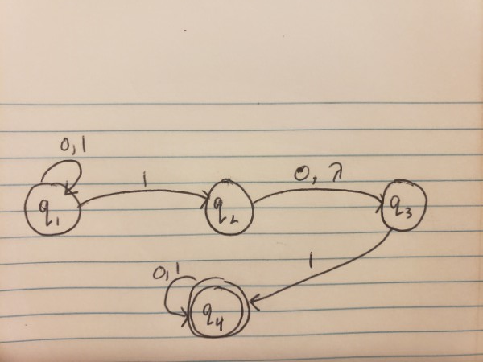

State Diagram

- Input: 010110
  - Start at $q_1$
  - Read 0, stay in $q_1$
  - Read 1, split into $q_1$ and $q_2$
  - With $\lambda$ split into $q_3$
    - Now there are three states running in parallel: $q_1, q_2. q_3$
    - $q_1$ goes to $q_1$, $q_2$ goes to $q_3$, $q_3$ dies
  - $q_2$ goes to $q_4$
  - Input is accepted because it reaches an accepted state but we keep going because there is more input to be read
  - $q_1$ gives $q_1, q_2, q_3$
  - $q_2$ dies with 1
  - $q_3$ goes to $q_4$
  - $q_4$ stays in $q_4$, the string is accepted

# Example

- Let $A$ be the language that has all binary strings that have a 1 three positions from the end of the string
  - i.e. 00101 $\in$ A, 11011 $\notin$ A
- NFA for A

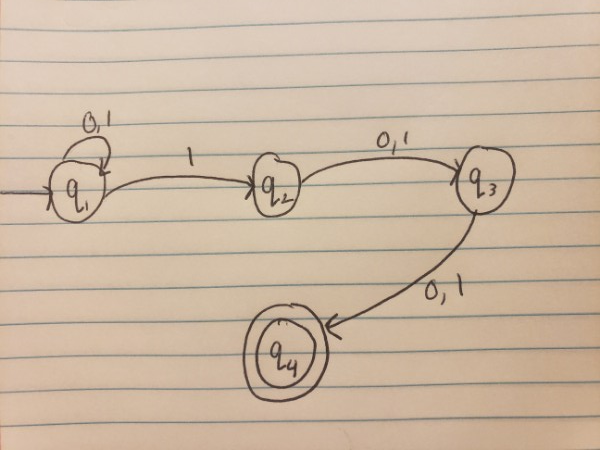

State Diagram

- DFA for A

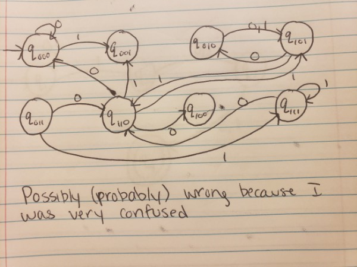

State Diagram

# TA Office Hours

- Krishna: TUE 10:30-12:30 DEH 115
- Mohammad: WED 11:00-1:00 DEH 115
- Office hours, names, emails are on website